## Introduction and Assignment

It is now possible to collect a large amount of data about personal movement using activity monitoring devices such as a Fitbit, Nike Fuelband, or Jawbone Up. These type of devices are part of the “quantified self” movement – a group of enthusiasts who take measurements about themselves regularly to improve their health, to find patterns in their behavior, or because they are tech geeks. But these data remain under-utilized both because the raw data are hard to obtain and there is a lack of statistical methods and software for processing and interpreting the data.

This assignment makes use of data from a personal activity monitoring device. This device collects data at 5 minute intervals through out the day. The data consists of two months of data from an anonymous individual collected during the months of October and November, 2012 and include the number of steps taken in 5 minute intervals each day.

The data for this assignment can be downloaded from the course web site:

Dataset: Activity monitoring data included in this GitHub Repository The variables included in this dataset are:

- steps: Number of steps taking in a 5-minute interval (missing values are coded as NA)
- date: The date on which the measurement was taken in YYYY-MM-DD format
- interval: Identifier for the 5-minute interval in which measurement was taken
- The dataset is stored in a comma-separated-value (CSV) file and there are a total of 17,568 observations in this dataset.

## Requirement 1: Code for reading in the dataset and/or processing the data

## unzip the raw data file and place in your working directory

## Keep the copy of the raw data before processing in the repository

```r
library(data.table)
```

```r
library(ggplot2)
library(scales)
library(lubridate)
library(plyr)
ActivityData <- read.csv("activity.csv")
ActivityData$day <- weekdays(as.Date(ActivityData$date))
ActivityData$date <- as.POSIXct(ActivityData$date, format="%Y-%m-%d")
summary(ActivityData)
```

```
##      steps             date                        interval
##  Min.   :  0.00   Min.   :2012-10-01 00:00:00   Min.   :   0.0
##  1st Qu.:  0.00   1st Qu.:2012-10-16 00:00:00   1st Qu.: 588.8
##  Median :  0.00   Median :2012-10-31 00:00:00   Median :1177.5
##  Mean   : 37.38   Mean   :2012-10-31 00:25:34   Mean   :1177.5
##  3rd Qu.: 12.00   3rd Qu.:2012-11-15 00:00:00   3rd Qu.:1766.2
##  Max.   :806.00   Max.   :2012-11-30 00:00:00   Max.   :2355.0
##  NA's   :2304
##      day
##  Length:17568
##  Class :character
##  Mode  :character
##
##
##
##
```

## What is mean total number of steps taken per day?

## Requirement 2: Histogram of the total number of steps taken each day

## use na.rm = TRUE to remove NA

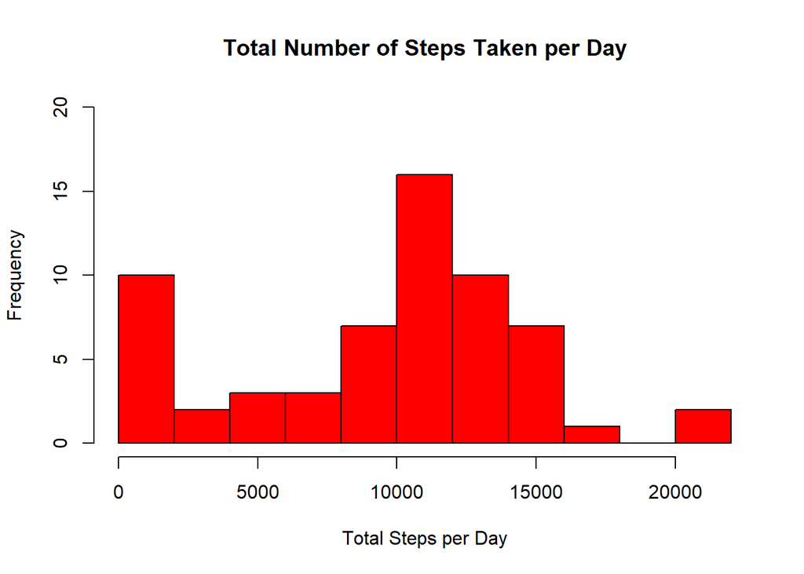

```r
ActivityDataStepsByDay <- with(ActivityData, aggregate(steps, by = list(date), FUN = sum, na.rm = TRUE))
names(ActivityDataStepsByDay) <- c("date", "steps")
hist(ActivityDataStepsByDay$steps, main = "Total Number of Steps Taken per Day", xlab = "Total Steps per Day", col = "red", ylim = c(0,20), breaks = 10)
```

## Requirement 3: Mean and median number of steps taken each day

```r
mean(ActivityDataStepsByDay$steps)
```

```
## [1] 9354.23
```

```r
median(ActivityDataStepsByDay$steps)
```

```
## [1] 10395
```

## What is the average daily activity pattern?

## Requirement 4: Time series plot of the average number of steps taken

## remove na

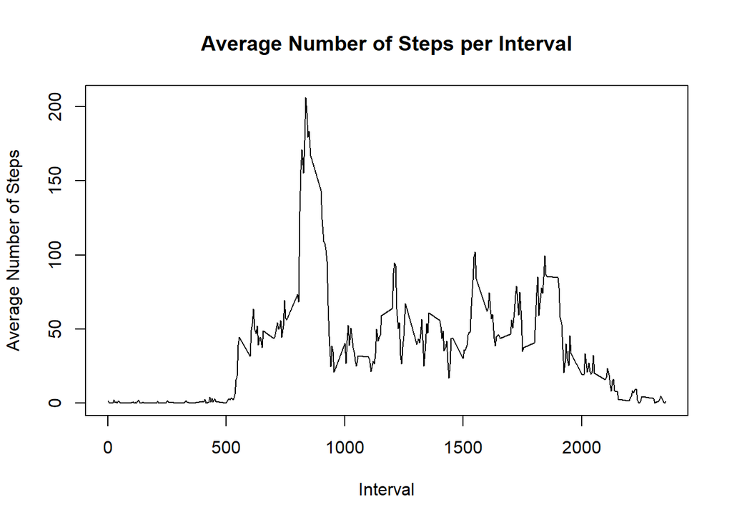

```r
ActivityDataInterval <- aggregate(ActivityData$steps, by=list(ActivityData$interval), FUN=mean, na.rm=TRUE)
names(ActivityDataInterval) <- c("interval", "mean")
plot(ActivityDataInterval$interval, ActivityDataInterval$mean, type = "l", xlab="Interval",  main = "Average Number of Steps per Interval", ylab = "Average Number of Steps")
```

## Requirement 5: The 5-minute interval that, on average, contains the maximum number of steps

```r
ActivityDataInterval[which.max(ActivityDataInterval$mean), ]$interval
```

```
## [1] 835
```

## Requirement 6: Code to describe and show a strategy for imputing missing data

## Determine how many rows have na

## use match to get the mean of the interval data used in requirement 4 and 5

## use transform to select mean of internal data for NA OR actual steps and SUM

```r
nrow(ActivityData[is.na(ActivityData$steps),])
```

```
## [1] 2304
```

```r
ForNASteps <- ActivityDataInterval$mean[match(ActivityData$interval, ActivityDataInterval$interval)]

ActivityDataWithoutNA <- transform(ActivityData, steps = ifelse(is.na(ActivityData$steps), yes = ForNASteps, no = ActivityData$steps))

ActivityDataTotal <- aggregate(steps ~ date, ActivityDataWithoutNA, sum)
```

## Requirement 7: Histogram of the total number of steps taken each day after missing values are imputed

## Same histogram as before with green and get the mean and median

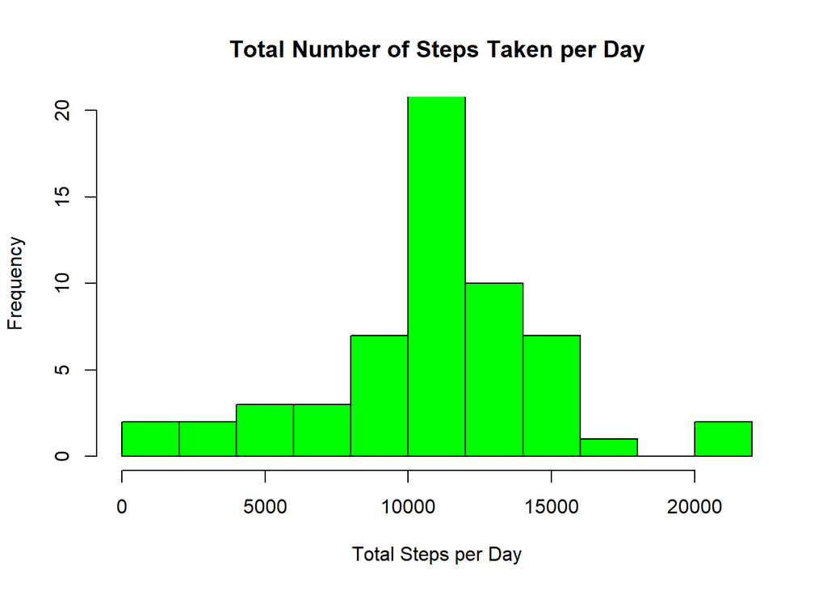

```r
names(ActivityDataTotal) <- c("date", "steps")

hist(ActivityDataTotal$steps, main = "Total Number of Steps Taken per Day", xlab = "Total Steps per Day", col = "green", ylim = c(0,20), breaks = 10)
```

```r
mean(ActivityDataTotal$steps)
```

```
## [1] 10766.19
```

```r
median(ActivityDataTotal$steps)
```

```
## [1] 10766.19
```

## Are there differences in activity patterns between weekdays and weekends?

## Requirement 8: Panel plot comparing the average number of steps taken per 5-minute interval across weekdays and weekends

## use weekdays to determine day of week and ifelse to set day of week to Weekend or Weekday

## use ggplot2 library to plot both day types

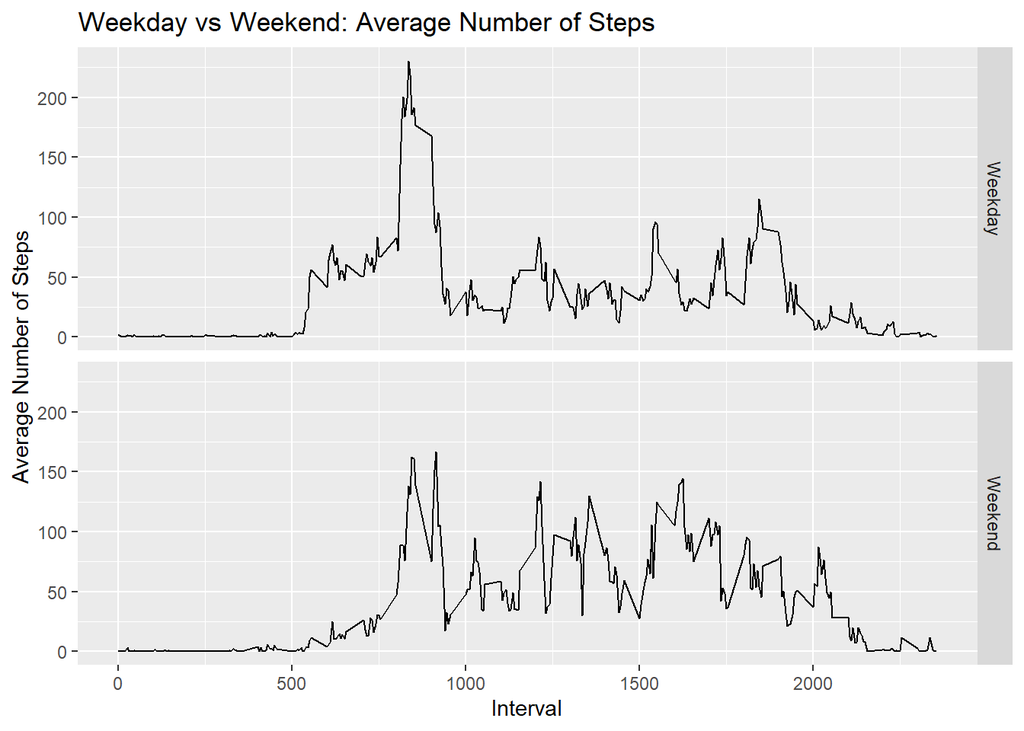

```r
ActivityDataWithoutNA$weekday <- weekdays(ActivityDataWithoutNA$date)

ActivityDataWithoutNA$DayType <- ifelse(ActivityDataWithoutNA$weekday=='Saturday' | ActivityDataWithoutNA$weekday=='Sunday', 'Weekend','Weekday')

ActivityDataByDayType <- aggregate(steps~interval+DayType, data=ActivityDataWithoutNA, FUN=mean)

ggplot(ActivityDataByDayType, aes(interval, steps)) + geom_line() + facet_grid(DayType ~ .) +
        xlab("Interval") + ylab("Average Number of Steps") + ggtitle("Weekday vs Weekend: Average Number of Steps")
```

## Requirement 9: All of the R code needed to reproduce the results (numbers, plots, etc.) in the report is in this RMD file.